# RIBBiTR Bd qPCR results comparison

RZ Lab vs. SNARL

Author

Cob Staines & Claude Code

Published

October 20, 2026

# 1 Summary of Findings

- **Question:** Are Bd detections and loads measured by the RZ lab and the SNARL lab comparable? If not, how can we make them more comparable?
- **Hypothesis:** *“SNARL qPCR more often fails to detect Bd at low loads”* is **moderately supported** (95% probability).
- **Zeros (Bd negatives):** the SNARL pipeline **misses more low-load infections**. A SNARL zero is weaker evidence that a frog is uninfected than an RZ zero, and zeros cannot be deterministically converted to probable loads.
- **Positive loads:** SNARL loads (PrepMan extraction + SNARL qPCR) are about **1.8× lower** than RZ loads (Qiagen extraction + RZ qPCR). **Add 0.26 to log10 SNARL loads to convert**.
- **Where the difference comes from:** almost entirely the **extraction step** (PrepMan vs Qiagen). The two labs’ **qPCR steps agree** on positive samples.

# 2 Purpose

Both labs measure Bd infection load by swabbing frogs, extracting DNA from the swab, and quantifying Bd DNA by qPCR. The two labs use different protocols:

| Step | RZ lab | SNARL lab |
| --- | --- | --- |
| DNA extraction | Qiagen DNeasy | PrepMan |
| qPCR | RZ protocol and Pisces plasmid standard | SNARL protocol and Briggs plasmid standard |

We want to know whether loads from the two labs are on the same scale, and if not, how to convert between them. The group’s working **hypothesis** is that **SNARL’s qPCR more often fails to detect Bd at low quantities** than the RZ qPCR protocol.

We ask three questions:

1. Does **precision** (“noise” e.g. between replicates) differ between the two labs?
2. Does the **qPCR step** give different quantities at the two labs?
3. Does the **extraction step** give different quantities at the two labs?

# 3 Experimental Design

81 frogs (60 collected by RZ Lab in Pennsylvania, 21 collected by SNARL in the Sierra Nevada; after one exclusion, see below) were each swabbed in duplicate (swab A and swab B). The swabs were then split between the labs so that each frog yields three results:

| Result | Swab | Extracted by | qPCR by |
| --- | --- | --- | --- |
| 1 | A | collecting lab | collecting lab |
| 2 | A (same extract as result 1) | collecting lab | other lab |
| 3 | B | other lab | other lab |

This design lets us separate the two steps:

- **Results 1 vs 2** use the *same DNA extract*, so any difference is due to the **qPCR** step.
- **Results 2 vs 3** use the *same qPCR lab* on extracts made by the two labs, so any difference is due to the **extraction** step (plus natural swab-to-swab variation, as these are different swabs).

In total there are 235 results. **56% are zero** (Bd not detected): a zero may mean the frog is uninfected, or that the load was too low for the pipeline to detect.

One frog was excluded: on the same extract, RZ detected nothing but SNARL measured about 10⁸ copies. Lab notes flag this as likely contamination or a sample mix-up.

We also used earlier **replicate** samples from the RIBBiTR database (the same swab run twice, or two swabs from the same frog) to learn how much results vary *within* a lab.

**Data sources**

- Experiment data: `qpcr_compare_data_260904.xlsx`. Database replicates: ITS1 results from both labs, passing (or lacking) the internal positive control, excluding the experiment’s own swabs.
- Loads are ITS1 copies per swab, corrected for each lab’s dilution; the two labs use different ITS1 plasmid standards.
- Replicates: swab replicates exist only for RZ (Qiagen–RZ). Same-swab replicates (the same swab measured more than once) exist for only 13 swabs. Database records cannot reliably tell whether these were qPCR re-runs of a stored extract or re-extractions (extraction dates are mostly missing, and SNARL extraction plate names copy the qPCR plate name), so they are treated as one type. Replicate definitions and diagnostics are in `rz_snarl_qpcr_diagnostics.qmd`.
- Because of the crossed design, some pairwise comparisons involve only one population (e.g. PrepMan–RZ vs Qiagen–RZ is SNARL-collected frogs only), so population and lab effects can be confounded when comparing raw panels. The model compares labs *within* frogs to avoid this.

# 4 Exploring the data

## 4.1 Replicate data

Each point is a pair of results from the RIBBiTR database, measured within one lab: the same swab measured twice (same-swab replicates; either a qPCR re-run of the stored extract or a re-extraction, we could not distinguish in our records), or two swabs from the same frog capture (swab replicates).

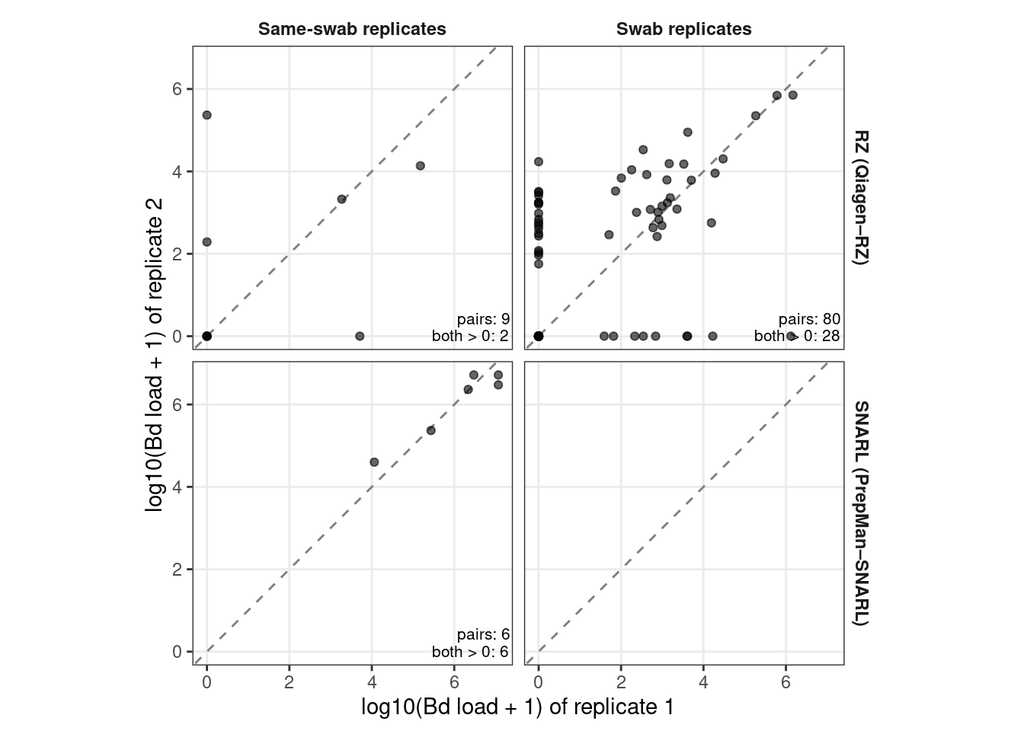

- **Replicates are sparse, mostly from RZ.** SNARL has no swab replicates and only a handful of same-swab replicates. As a result SNARL-specific noise cannot be estimated independently (see Noise results below).
- **Most RZ same-swab pairs are both zero or disagree on detection**, so these say more about detection than about quantity.
- **The few SNARL replicates are all high-load and agree closely.** They cannot show whether SNARL is noisy at low loads, where the detection differences between the labs appear.

## 4.2 Experiment data

Each panel compares two pipelines (extraction method – qPCR lab) on the same frogs.

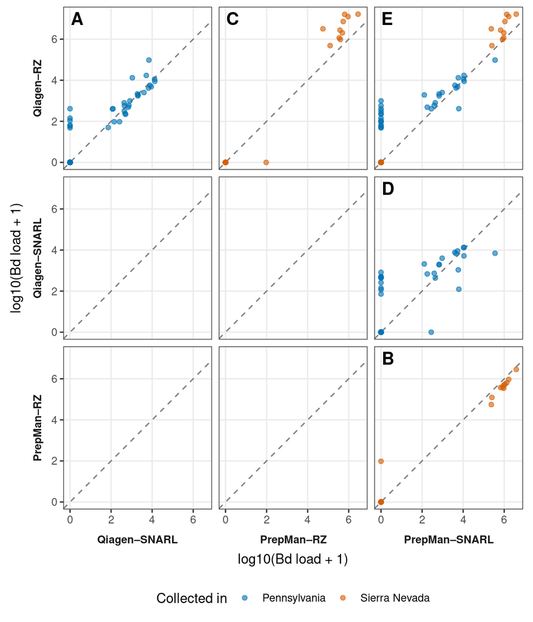

- **A and B (same swab, same extract, different qPCR lab):** positive results sit close to the 1-to-1 line, so the two qPCR labs agree well on quantities. Several low-load extracts were detected by RZ but not SNARL (left edge of A).
- **C and D (different swab, different extraction method, same qPCR lab):** many frogs sit on the left edge, detected with Qiagen but not PrepMan, and positive results sit on or above the 1-to-1 line. Additional scatter may result from distinct swabs.
- **E (different swab, different extraction method, different qPCR lab):** again we see low loads detected with Qiagen and not with PrepMan, with higher loads generally slightly above the 1-to-1 line. Additional scatter may result from distinct swabs.
- **Across panels:** disagreements about detection happen mostly at low loads (below about 10³ copies).

# 5 Analysis

We used two Bayesian models (R, `brms`) to tease out the effects of different steps in the Bd qPCR pipeline on quantitative results, plus a third for RZ qPCR noise only:

0. **qPCR noise model:** using RZ eDNA extracts run in triplicate wells on one plate, estimate how much RZ qPCR wells vary, and how this depends on load. Used for comparison only (see Noise); it does not feed into the other models.
1. **Replicate model:** using the replicate dataset, estimate how variable results are between swabs and between repeat measurements of the same swab *within* a lab, and how the chance of detecting Bd rises with load.
2. **Experiment model:** using the experimental dataset, estimate each frog’s true load from all its results, then how each pipeline shifts that load up or down. Zeros are treated as “not detected” rather than “no Bd”, with detection becoming more likely at higher loads. Results from the replicate model (1) were used as starting information (priors) in the experiment model (2).

Because each frog is measured by both labs, the lab comparisons are made **within frogs**. Differences between frog populations (e.g. Rana muscosa generally carry much higher loads) do not impact the lab comparison.

**Model formulas**

**Model 0 (qPCR noise)**, `rz_snarl_qpcr_model0_qpcr_noise.qmd`: hurdle-lognormal model of eDNA triplicate wells, with correlated Student-t group-level intercepts per sample in `mu` and `hu` (detection vs. load), and `sigma` depending on the sample’s observed mean log10 load (log-linear, as for Poisson sampling of copies). Within-plate RZ noise only; not used as a prior.

**Model 2a (experiment, no slope)**, `rz_snarl_qpcr_model2_experiment.qmd`: non-linear hurdle-lognormal model, `mu = L + d`, where `L` is the latent swab load (frog-level intercept, plus a swab-level intercept for swab + extraction noise, shared by results 1 and 2) and `d` holds constant biases for PrepMan extraction and SNARL qPCR. Detection (`hu`) has extraction and qPCR effects plus a frog-level intercept correlated with the frog’s load. The residual (qPCR) noise is pooled across labs and learned from the experiment’s shared extracts (weakly informative prior). Priors on the swab SD and detection SD come from Model 1.

**Model 2b (experiment, with slope)** adds a term letting the SNARL–RZ qPCR difference change with load, `s·(L − L_ref)`: a test of whether SNARL qPCR under-quantifies low *positive* loads (a quantity bias, separate from the detection hypothesis, which is tested by the SNARL qPCR effect on `hu`). Results are in Does the qPCR difference change with load?; the simpler constant-bias Model 2a is used elsewhere.

**Simplifications, and why:** lab-specific qPCR noise and method-specific extraction noise were each tried, but the design only identifies their *combined* values, so both were pooled. An extraction × qPCR interaction and population (collecting lab) effects were left out to focus on the lab differences.

# 6 Results

## 6.1 Extraction

**PrepMan yields fewer copies than Qiagen**

On the same frogs, **PrepMan extracts give 0.29 (95% CI 0.06 to 0.53) log10 lower loads than Qiagen**, about **1.97× fewer copies**. PrepMan also produces **more non-detects**.

## 6.2 qPCR

**Labs agree on amounts; SNARL probably misses more low-load samples**

**Amounts.** When both labs detect Bd on the *same* DNA extract, **SNARL qPCR differs from RZ qPCR by only 0.03 (95% CI -0.11 to 0.17) log10**, which is effectively no difference. This holds across the load range: there is no sign that SNARL under-measures low positive loads (see Does the qPCR difference change with load?).

**Detection (the hypothesis).** On the same extract, SNARL qPCR returns more zeros than RZ. There is a **95% probability** that SNARL qPCR is less sensitive: the odds of a zero are about **2.6× higher** (95% CI 0.9 to 8.6). SNARL qPCR needs about **0.40 (95% CI -0.05 to 0.95) log10 more Bd** to reach 50% detection. Because detection rises steeply with load, this gap matters mainly at low loads, as hypothesised. In the raw data (panel A), several low-load extracts were detected by RZ but not SNARL. **The hypothesis is moderately supported:** the direction is clear, but the interval still includes no difference.

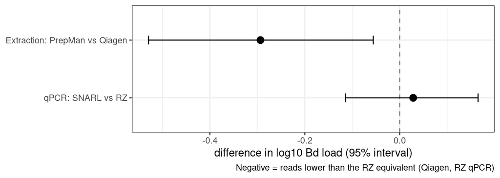

### 6.2.1 Does the qPCR difference change with load?

Model 2b checks whether SNARL qPCR under-measures *low positive* loads more than high ones: a bias in the amount measured, separate from the detection hypothesis. It lets the SNARL − RZ difference on the same extract change with true load, by a slope `s` around the median positive load value 3.6 log10 copies per swab.

- **Slope:** `s` = 0.03 (95% CI -0.06 to 0.12) (77% probability that `s > 0`). The interval includes 0 (no change with load).
- **Implied difference (SNARL − RZ, log10):** -0.04 (95% CI -0.25 to 0.19) at 2 log10 copies per swab, 0.02 (95% CI -0.12 to 0.15) at the typical load, and 0.10 (95% CI -0.14 to 0.32) at 6 log10.
- **Model comparison:** leave-one-out cross-validation found no difference between Model 2b and the constant-bias Model 2a (`elpd_diff` = -1.0, SE 1.4).

**Conclusion:** there is no evidence that the qPCR difference depends on load, so the simpler constant-bias **Model 2a** is used for all other results and for the conversion between labs below.

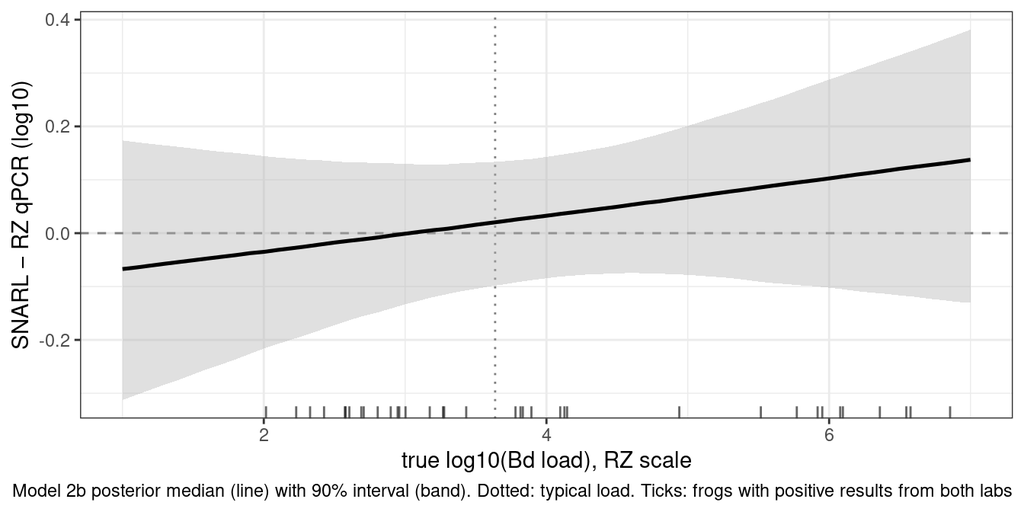

## 6.3 Detection

**SNARL pipeline misses more low-load infections**

Both steps of the SNARL pipeline lean toward more non-detects: SNARL qPCR (the hypothesis; compare Qiagen–RZ and Qiagen–SNARL) and, more clearly, PrepMan extraction. The chart shows the chance of detecting Bd at each true load for each pipeline. At high loads, every pipeline detects almost all infections; at low loads, the PrepMan–SNARL pipeline detects fewer. Ticks along the top (detected) and bottom (not detected) are the actual results, placed at each frog’s estimated true load.

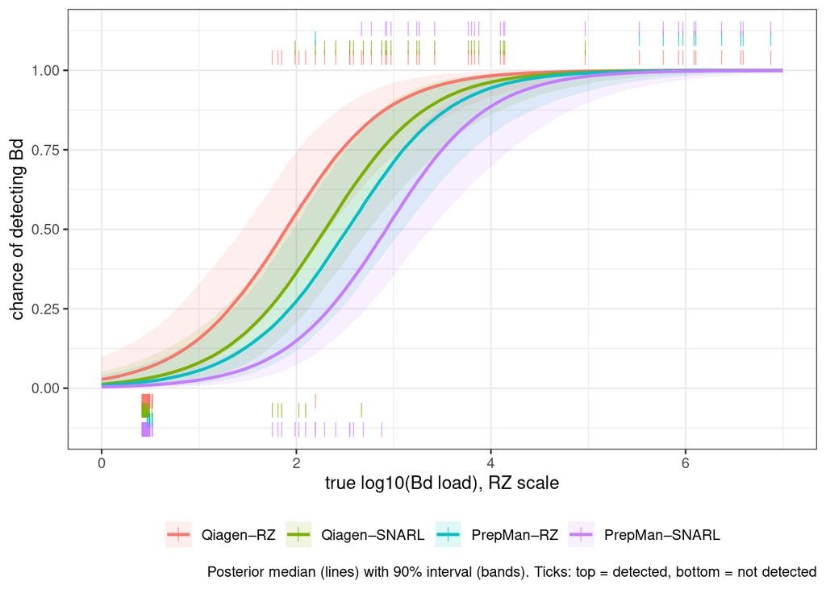

log10 loads at which each pipeline detects Bd 50% and 90% of the time:

| Pipeline | 50% detection (log10 load) | 90% detection (log10 load) |
| --- | --- | --- |
| Qiagen–RZ | 1.9 (1.4–2.5) | 3.1 (2.5–4.1) |
| Qiagen–SNARL | 2.3 (1.9–2.9) | 3.5 (3.0–4.5) |
| PrepMan–RZ | 2.6 (1.9–3.3) | 3.7 (3.0–4.9) |
| PrepMan–SNARL | 3.0 (2.5–3.6) | 4.1 (3.5–5.4) |

## 6.4 Noise

How much a single result varies if the measurement is repeated: re-running qPCR on the same DNA extract, or taking a new swab from the same frog (which adds swab-to-swab and extraction variation on top of qPCR noise). Grey: estimate from the replicate data, which the experiment model used as starting information. Black: the experiment model’s estimates, after adding the experiment data. Light grey: RZ well-to-well noise within one plate (eDNA triplicates, Model 0), averaged over the loads of the experiment’s positive results (by copies in the well). qPCR noise comes from the experiment only: the replicate records cannot reliably separate qPCR re-runs from re-extractions.

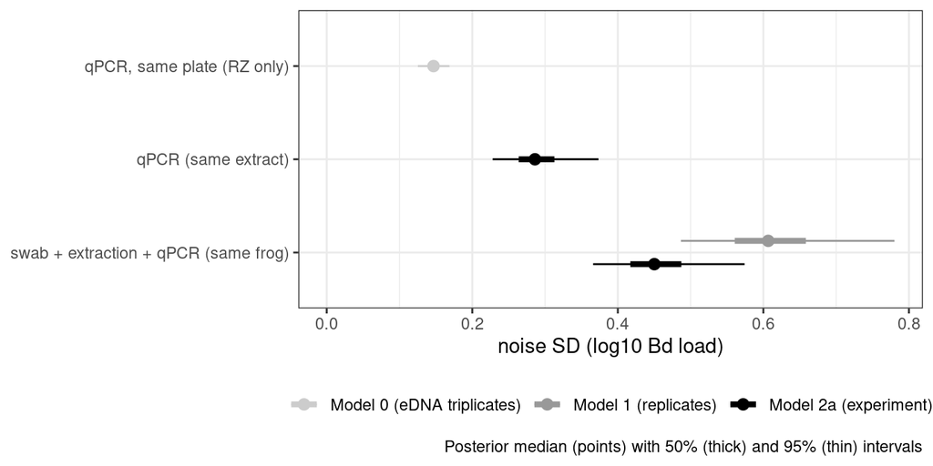

Re-running qPCR on the same extract moves a result by about **0.29 log10**; a new swab from the same frog moves it by about **0.45 log10** in total. Most of that comes from swab-to-swab (and extraction) variation, so a single swab is an imperfect snapshot of a frog’s load. The experiment cannot separate extraction noise from swab-to-swab noise, and the replicate records cannot reliably tell re-extractions from qPCR re-runs, so extraction noise is not reported on its own.

Within one plate, RZ qPCR wells of the same extract differ by about **0.15 log10** at the experiment’s loads. This is strongly load-dependent: about 0.25 log10 at 2 log10 per swab (≈ 2.5 copies per reaction) but 0.10 at 3.5 log10 (≈ 80 copies), as expected from random sampling of a few copies into each well. It is a lower bound on the experiment’s qPCR noise, which also includes differences between runs and labs (separate plates and standard curves).

We **cannot say whether one lab is noisier** than the other (Key question 1). The experiment only measures the labs’ *combined* noise, and replicate data from SNARL were too sparse.

# 7 Converting between labs

For a **positive** Bd load (ITS1 copies per swab), add the correction to the log10 load, or multiply copies by the multiplier, to put it on the **RZ (Qiagen extraction, RZ qPCR) scale**:

| From pipeline | Add to log10 load (95% CI) | Multiply copies by (95% CI) |
| --- | --- | --- |
| Qiagen–SNARL | -0.03 (-0.17 to +0.11) | ×0.94 (0.68 to 1.30) |
| PrepMan–RZ | +0.29 (+0.06 to +0.53) | ×1.97 (1.14 to 3.38) |
| PrepMan–SNARL | +0.26 (+0.02 to +0.50) | ×1.84 (1.05 to 3.13) |

**For standard SNARL data (PrepMan + SNARL qPCR):**

log10(RZ-equivalent load) = log10(SNARL load) + 0.26.

When to be careful:

- **Zeros cannot be converted.** A SNARL zero is more likely than an RZ zero to hide a low-load infection, so **prevalence** from SNARL data will tend to be lower. Compare prevalence using the detection curves, not the conversion.
- **Use the conversion on the log scale.** It shifts typical (median) loads; converting *average* loads on the raw copies scale needs more care.
- **It is specific to these protocols and standards.** If either lab changes its extraction kit, qPCR protocol, or plasmid standard, the conversion needs re-checking.

# 8 Some Limitations

- **Noise in the qPCR process is grouped among labs.** The experiment identifies only combined qPCR noise and combined extraction noise, and SNARL replicates were sparse. This could be improved upon with a stronger rep[licate dataset from each lab.
- **Small sample at low loads.** Many results are zero, so conclusions about very low loads (and the detection curves there) rest on few positive results and model assumptions. More low-load samples shared between labs, or replicated within labs could help to reduce model uncertainty.
- **Shared detection slope.** The models assume the pipelines’ detection curves have the same shape and differ only in position.
- **One snapshot of protocols.** Results apply to the kits, protocols and standards in use during the experiment. Impacts beyond these protocols are not assessed.

# 9 Discussion points

- What are the applications of these findings?
- Is a single conversion factor (×1.8) good enough for combined analyses, or should we propagate uncertainty in this factor as well?
- Zero conversions: How should historical SNARL zeros be handled in prevalence comparisons (for example, restricting comparisons to loads above the detection thresholds)?
- Is the extraction difference large enough to consider aligning extraction methods going forward? For what applications?
- Would a small targeted follow-up with existing replicates be worthwhile to answer the noise question?